```python
from IPython.core.display import display, HTML
display(HTML("<style>.container { width:100% !important; }</style>"))
```

# Project 1: Data analysis

#### Group 11

Github: https://github.com/rohullaa/project1

## Bayesian approch

In order to predict the effect of genes on symptoms, we will use a simple Bayesian model. We consider these hypothesis:

$$\mu_0: P(symptoms|genes) = P(symptoms)$$$$\mu_1: P(symptoms|genes) \neq P(symptoms)$$

In order words, does the genes have any effect on the symptoms or not? If it does, which genomes are the most relevant for the preventing the symptoms?

We let Y be the symptoms and our X the genes. Y is an 8 bit vector for each observation, with 1 or zero for each bit. X is an 128 with the same charectaristic as Y.

The probability distribution of $ Y $ depends on an unknown parameter that we assume to be stochastic. We call this unknown parameter $\theta$, or in our program, $ p $.

The formulation under is an alternative formulation of the the previous hypotesis. Does the parameter that the probability distribution of Y depend on, depend on X or not. $ \mu_0 $, our null, says that it does not. $\mu_1 $, the alternative hypothesis claims it does. We assume the Beta-Bernoulli model:

$$\mu_0: \theta_0 \sim Beta(\alpha_0 , \beta_0) , \ \ \ Y | \theta_0 $$$$\mu_1: \theta_{1,x_t} \sim Beta(\alpha_{1,x_t} , \beta_{1,x_t}) , \ \ \ y_t | x_t \sim bernoulli(\theta_{1,x_t}) $$

Given the data, D, we try to estimate

$$ P(\mu | D) = \frac{P_{\mu} (D) \cdot \xi(\mu)}{\sum_{i=1} ^n P_{\mu_1}(D) \cdot \xi(\mu_1)} $$

For simplicity, let $\mu = \mu_0$ or $\mu = \mu_1$. We define the posterior belief:

Let $P_{\mu} (D) = P(\mu |D)$ for $D = (x_t, y_t,x_{t-1},y_{t-1})_{t=1} ^T $ for a spesific gene X, and let $x_t$ be the value (0 or 1) of the gene for one observation, t, then $x_{t-1}$ is a vector of all the values for the previous observations including t-1. Further, let $y_t$ be the the value (0 or 1) of symptom Y for observation t defined in the same way. We assume that the different observations are independent. That is,

$$ \begin{align*}P_{\mu}(D) & = P(y_1,...,y_t \cup x_1,...,x_t) \\ & = \prod_{i=1}^{t} P(y_i | x_i,x_{i-1} , y_{i-1}) \end{align*} $$

With these assumptions, we can estimate $P_{\mu} (D)$: $$ P(y_t | x_t,x_{t-1} , y_{t-1}) = \int_{\theta} P_{\theta}(y_t|x_t) \cdot \xi(\theta|x_{t-1},y_{t-1})$$

This makes adding new observations and updating beliefs easy. It works if we assume that a new observation is independent of the previous.

This estimate is called the marginal likelihood (posterior predictive distribution). It is a compound distribution. The probabilty $P(y_t | x_{t})$ is stochastic in $\theta$, so we have to integrate over all values of $\theta$. Every time a new observation is added we compute $$P(y_t | x_{t},x_{t-1}, y_{t-1})$$, and recalculate $$ \prod_{i=1}^{t} P(y_i | x_i ,x_{i-1}, y_{i-1}) $$.

When calculating $$ P(\mu | D) = \frac{P_{\mu} (D) \cdot \xi(\mu)}{\sum_{i=1} ^n P_{\mu_i}(D) \cdot \xi(\mu_i)} $$ we are sequentially updating our belief every time a new observation is added. For every update $\xi(\mu)$, $P(\mu | D)$ is from the previous iteration, exept for in the very first iteration when $\xi(\mu)$ will cancel because it's constant.

This integral simplifies to the expectation of the posterior:

$$ P(y_t | x_{t},x_{t-1},y_{t-1}) = \int_{\theta} P_{\theta}(y_t) \cdot d \xi(\theta|y_{t-1}) = \frac{\alpha_{t,x_t}}{\alpha_{t,x_t} + \beta_{t,x_t}}.$$

Hence, we will not be computing the integral. Instead, we will update $\alpha$ and $\beta$ in a way that depends on the data.

Now, focusing on $\mu_1$, we will use the Beta-Bernoulli conjugate prior. It is a Bernoulli distribution, a binomial with $n=1$, where the probability of success at each trial is a random variable. This random variable is assumed to be beta distributed. Since Y is either 1 or 0 it is reasonable to assume that $Y|X$ is Bernoulli distributed.

It is also convinient because of its conjugate prior property. We can now calculate $P( D | \mu_1) = \prod_{i=1}^{t} P(y_i | x_i ,x_{i-1}, y_{i-1}) $ beacuse we know that the marginal likelihood (posterior predictive distribution) is composed of a Bernoulli distribution and a beta distribution $ P(y_t | x_t , y_{t-1}) = \int_{\theta} P_{\theta}(y_t|x_t) \cdot \xi(\theta|x_{t-1},y_{t-1})$. For each iteration we get that $P_{\mu} (D)$ is itself beta distributed.

The same integral calculation is done for $P(D | \mu_0)$ but now the marginal likelihood is assumed to be independent of the data.

For convenience, instead of calculating $P(D |\mu_1)$ directly, we will calculate $log(P(D|\mu_1))$, and in the end do $e^{log(P(D|\mu_1))}$ to obtain the desired probability.

The calculation is done sequentially. For each iteration we have a new observation, a new set of genes. We continously update the posterior belief, and put this into a list. The belief gets updated through calculating the marginal likelihood in each iteration, and then taking the product between this marginal likelihood and all the previous marginal likelihoods. In the end we obtain the estimate $$ P(\mu | D) = \frac{P_{\mu} (D) \cdot \xi(\mu)}{\sum_{i=1} ^n P_{\mu_i}(D) \cdot \xi(\mu_i)} $$.

For each gene we then reject the null if $P(\mu_1|D) > s$ for a given threshold $0 < s < 1$.

## The effect

Once we have the most relevant genes we will look at the individual effect of each gene on symptoms, i.e the probability of having a symptom given that you have one of these genes.

This will be done in a somewhat simplistic fashion. As described above, we assume a Beta-Bernoulli conjugate prior that leads to a beta distributed posterior belief with parameters $\alpha$ and $\beta$. We will update $\alpha$ and $\beta$ sequentially when reading through the data. For a given gene $x_i$ and symptom $y_i$, if $x_i = 1$, $\alpha_i = \alpha_{i-1} + 1$ if $y_i = 1$ and $\beta_i = \beta_{i-1} + 1$ if $y_i = 0$. This way we get the expected value of our posterior $$\hat{p} = \frac{\alpha_0 + k}{\alpha_0 + \beta_0 + n} = \frac{\alpha}{\alpha + \beta}$$ where $k$ is the number of "successes" and $n$ is the number of observations where $x_i = 1$ and $\alpha_0$ and $\beta_0$ are the parameters of the prior ditribution. Given a large amount of data the choice for $\alpha_0$ and $\beta_0$ are not of much significance as we expect the results to converge to the "true" values.

## Estimating the efficacy of vaccines

We estimate the efficacy of the vaccines by $$ 100 \cdot (1-IRR)$$ where IRR is the ratio of the vaccinated incidence rate and not vaccinated incidence incidenes ([link](https://www.nejm.org/doi/full/10.1056/NEJMoa2034577)). We model the relationship for each symptom as given below:

$r_v = P(symptom = 1 | vaccine = 1)$ and

$r_n = P(symptom = 1 | vaccine = 0)$

to obtain $IRR = 100 * [1 - r_v / r_n]$

Our prior belief is that $r_v$ and $r_n$ are equal for all symptoms. Prior to observing the data we assume that symptoms are independent from vaccines. We also assume that the probability of symptom given gene are beta distributed, with the same $\alpha$ and $\beta$ parameter for all symptoms. To estimate $\alpha$ and $\beta$ we first find the frequency of people having a certain symptom for both the vaccinated group and the non vaccinated group and devide these frequencies by the total number of observations. We let this be the estimated expected value of $r_v$ and $r_n$. We have

$$V=frequency \; of \; people \; having \; a \; certain \; symptom \; for \; the \; vaccinated$$$$NV=frequency \; of \; people \; having \; a \; certain \; symptom \; for \; none \; vaccinated$$$$T=Total \; number \; of \; observations$$$$E[r_v]=\frac{\alpha}{\alpha+\beta}=\frac{V}{T} $$

$$E[r_n]=\frac{\alpha}{\alpha+\beta}=\frac{NV}{T}$$

Our prior belief is given as $p=\frac{V}{T}=\frac{NV}{T}$.

So:

$$E[r_v]=E[r_n]=\frac{\alpha}{\alpha+\beta}=\frac{V}{T} $$

The expression we need to compute in order to get the estimated $\alpha$ and $\beta$ values for our prior belief is:

$$\frac{\alpha}{\alpha+\beta}=\frac{V}{T} $$

Setting $\beta=1$ we get $\alpha=\frac{\beta*p}{1-p}$.

$Posterior \propto Likelihood * Prior={n \choose k}\theta^k(1-\theta)^{n-k} \theta^{\alpha-1}(1-\theta)^{\beta-1} \propto \theta^{\alpha+k-1}(1-\theta)^{\beta+n-k-1}.$

We use the parameters of the posterior to genrate N numbers of the random variables, both for the vaccinated group and the none vaccinated group in order to find a 95% credible interval for our estimated efficacy of the vaccine on all the symptoms.

## Estimating the probability of vaccination side-effects.

Using the Bayes theorem, we will estimate the probability of vaccination side-effects. In other words, the probability of getting symptoms given that a person is vaccinated and has tested negative. $$p_1 = P(symptom | vaccine,covid') = \frac{P(symptom \cap vaccine,covid')}{P(vaccine,covid')} $$ $$p_2 = P(symptom | vaccine',covid') = \frac{P(symptom \cap vaccine',covid')}{P(vaccine',covid')} $$

We want to test the following hypothesis: $$ h_0: p_1 - p_2 \leq 0 $$ $$h_a: p_1 - p_2 > 0 $$

We make a confidence intervall for each symptom, and reject the null hypothesis if confidence intervall does not include zero.

In this task it seems appropiate to estimate confidence intervalls instead of doing the task of comparison through hypotesis testing.

The variables X and Y represents the number of individuals in each sample having a certain characteristic that defines $p_1$ and $p2$.Provided the population sizes are much larger than the sample sizes, the distribution of X can be choosen to be binomial with parameters m and $p_1$, and similarly, Y is choosen to be a binomial variable with parameters n and $p_2$. The samples are assumed to be independent of each other.Therefore X and Y are independent rv’s.

The estimator for $ p_1-p_2 $, the difference in population proportions, is the difference in sample proportions $\frac{X}{m} - \frac{Y}{n}$ . $ \hat{p_1} = \frac{X}{m}$ and $\hat{p_2} = \frac{Y}{m}$, the estimator of $ p_1-p_2 $ can be expressed as $\hat{p_1} - \hat{p_2}$.

$E[\hat{p_1} - \hat{p_2}]=p_1-p_2$ so $\hat{p_1} - \hat{p_2}$ is an unbiased estimate of $p_1-p_2$

$\hat{p_1}=\frac{X}{m}$ and $\hat{p_2}=\frac{y}{n}$ are aproximately normal distributed when m and n are large.

Refrence: Modern Mathematical Statistic with applications.

## The effect of treatments on alleviating symptoms

We are not interested in the outcomes for individuals who did not have any symptoms neither before nor after the treatment,since these individuals dont tell us anything about wether one had a positve of negative effect of the treatment.

We do this modelling task in a similar way that we did the modelling for vaccine efficacy. Since we now have data from before and after a treatment, we calculate the ratio of people who still have symptoms after treatment to the people who had symptoms before treatment for both the treated group and the control group.

We estimate the efficacy of the treatments based on this ratio

$$t_1 = P(symptom = 1 | treatment = 1)$ after treatment, $t_0 = P(symptom = 1 | treatment = 1) $$

before treatment.

$$n_1 = P(symptom = 1 | treatment = 0)$ after treatment, $n_0 = P(symptom = 1 | treatment = 0) $$

before treatment

$$r_t = t_1 / t_0$$

and

$$r_n = n_1 / n_0$$

to obtain $IRR = 100 * [1 - r_t / r_n]$

## Privacy

These data are health data and genomic data which are classified as sensitive personal data and have special protection under the [law](https://lovdata.no/dokument/NL/lov/2018-06-15-38/KAPITTEL_gdpr-2#gdpr/a9). It is not allowed to use such data unless some conditions are satisfied, such as prior consent from the people the data regards, or specifically for this case that use of the data is necessary for public health concerns. Such use does still require that special measures are taken to ensure that the rights of the registered individuals are protected.

The data we have is very precise, e.g. we have the age and income as decimal numbers with enough precision that they can be used to identify the people the data regards. One way to help rectify this could be to divide the data into age and income groups in a way that gives some k-anonymity with regards to these identifiers. However, considering we have 128 bits of the genome for each person, it is highly unlikely that we can give more than 1-anonymity without dropping this part of the data set.

## The modelling

We start by importing the libraries and loading the data.

```python
import pandas as pd
import numpy as np
import matplotlib.pyplot as plt
from scipy import stats
from scipy.special import btdtri
import random
from sklearnex import patch_sklearn
patch_sklearn()
from sklearn.model_selection import train_test_split, cross_val_score, GridSearchCV
from sklearn.metrics import classification_report
from sklearn.linear_model import LogisticRegression
from sklearn.svm import SVC
from sklearn.utils import resample
from imblearn.over_sampling import SMOTE
from imblearn.combine import SMOTEENN, SMOTETomek
from imblearn.pipeline import make_pipeline
import statsmodels.api as sm
```

```
Intel(R) Extension for Scikit-learn* enabled (https://github.com/intel/scikit-learn-intelex)
```

```python
obs_data = pd.read_csv("observation_features.csv")
treat_data = pd.read_csv("treatment_features.csv")
action_data = pd.read_csv("treatment_actions.csv")
outcome_data = pd.read_csv("treatment_outcomes.csv")

symptoms_names = ['Covid-Recovered', 'Covid-Positive', 'No-Taste/Smell', 'Fever', 'Headache', 'Pneumonia', 'Stomach', 'Myocarditis', 'Blood-Clots', 'Death',
        'Age', 'Gender', 'Income']
cols = ( symptoms_names +
         [f'Gene_{i+1:03}' for i in range(128)] +
         ['Asthma', 'Obesity', 'Smoking', 'Diabetes', 'Heart disease', 'Hypertension',
         'Vacc_1', 'Vacc_2', 'Vacc_3'])

obs_data.columns = cols
treat_data.columns = cols
outcome_data.columns = cols[:10]
action_data.columns = ['Treatment_1', 'Treatment_2']

symptoms = obs_data.iloc[:,:10]
genes = obs_data.iloc[:,13:141]
```

## The pipelines

In this section we indroduce **Pipeline_observational**. This pipeline will be used throughout problem. It contains the methods for modelling the effective genes, finding efficacy of the vaccines and the estimating the probability of sideeffects for all vaccines. We also introduce the **Pipeline_treatment** which contains methods for estimating the efficacy for treatments.

The pipelines will be run with generated data and tested before we evaluate it on real data.

```python
class Pipeline_observational():

    def __init__(self, obs_data=None):
        self.obs_data = obs_data
        self.symptoms = obs_data.iloc[:,:10]
        self.genes = obs_data.iloc[:, 10:139]
        self.vaccines = obs_data.iloc[:,-3:]
        self.symptom_names = symptoms.columns
        self.vaccine_efficay = []
        self.sideeffect_list = []

    def run_select_features(self, symptom, genes, threshold=0.8):
        """This function finds the selected features, then runs BIC test in order
        to see whether the model with selected features are better than the full model"""

        self.best_features = best_features = self.select_features(symptom,genes,threshold)
        self.important_genes = [col for col in genes.iloc[:,best_features].columns]
        return best_features

    def select_features(self, symptom, genes, threshold=0.8):
        """ Select the most important features of a data set, where X (2D)
        contains the feature data, and Y (1D) contains the target
        """

        X, Y = np.array(genes), np.array(symptom)
        n_features = X.shape[1]
        n_data =  X.shape[0]
        alpha_b = np.ones([n_features, 2 ])
        beta_b = np.ones([n_features, 2])
        log_p = np.zeros(n_features)

        log_null = 0
        alpha = 1
        beta = 1
        for t in range(n_data):
            p_null = alpha / (alpha + beta)
            log_null += np.log(p_null)*Y[t] + np.log(1-p_null)*(1 - Y[t])
            alpha += Y[t]
            beta += (1 - Y[t])
            for i in range(n_features):
                x_ti = int(X[t,i])
                p = alpha_b[i, x_ti] / (alpha_b[i, x_ti] + beta_b[i, x_ti])
                log_p[i] += np.log(p)*Y[t] + np.log(1-p)*(1 - Y[t])
                alpha_b[i, x_ti] += Y[t]
                beta_b[i, x_ti] += (1 - Y[t])
        log_mean=np.mean(log_p)
        log_mean2=np.mean(log_null)
        log_p=log_p-log_mean
        log_null=log_null-log_mean2
        p = 1 / (np.exp(log_null - log_p) + 1)
        return [i for i in range(n_features) if p[i] > threshold]

    def estimate_gene_effect(self,symptom, genome):
        """Given a genome and a symptom, we estimate the probability of having a symptom from the data"""
        symptom, genome = np.array(symptom), np.array(genome)
        alpha = 1
        beta = 1
        for t in range(genome.shape[0]):
            if genome[t] == 1:
                alpha += symptom[t]
                beta += (1 - symptom[t])

        return alpha/(alpha+beta)

    def estimate_vaccine_efficacy(self, group_pos: pd.DataFrame, group_neg: pd.DataFrame, symptom, prior_probs,show_result):
        """ Given a dataframe group_pos (vaccinated and covid positive) and group_neg (not vaccinated and covid postive) we estimate the efficacy of the vaccines"""

        if isinstance(symptom, int):
            symptom_index = symptom
            symptom_name = group_pos.keys()[symptom]
        else:
            symptom_name = symptom
            symptom_index = list(group_pos.keys()).index(symptom)

        group_pos_count = np.sum(group_pos[symptom_name] * group_pos.iloc[:,1])
        group_neg_count = np.sum(group_neg[symptom_name] * group_neg.iloc[:,1])

        v = group_pos_count/len(group_pos)
        n_v = group_neg_count/len(group_neg)

        if n_v == 0:
            print(f'{v}, {n_v}: Division by zero')
            return

        IRR = v/n_v

        efficacy = 100*(1- IRR)

        N = 100_000
        beta = 1
        p = prior_probs[symptom_index]
        alpha = beta*p/(1-p)

        samples_group_pos = stats.beta.rvs(alpha + group_pos_count, beta + len(group_pos) - group_pos_count, size=N)
        samples_group_neg = stats.beta.rvs(alpha + group_neg_count, beta + len(group_neg) - group_neg_count, size=N)

        samples_ve = 100 * (1 - samples_group_pos/samples_group_neg)
        lower = np.percentile(samples_ve, 2.5)
        upper = np.percentile(samples_ve, 97.5)

        if show_result == True:
            print(f'{symptom_name:15s}: {efficacy:3.3f} - ({lower:3.3f}, {upper:3.3f})')
        self.vaccine_efficay.append([efficacy,lower,upper])

    def print_vaccine_efficacy(self, vaccine: pd.DataFrame, not_vaccinated: pd.DataFrame,prior_probs, vaccine_type = False,show_result = True):
        """Given a set of vaccinated and unvaccinated data, we estimate the efficacy of all vaccines together and then one by one """

        if vaccine_type == True:
            vacc_1 = vacced[vacced['Vacc_1'] == 1]
            vacc_2 = vacced[vacced['Vacc_2'] == 1]
            vacc_3 = vacced[vacced['Vacc_3'] == 1]
            for v in vacc_1, vacc_2, vacc_3:
                for i, s in enumerate(self.symptom_names):
                    self.estimate_vaccine_efficacy(v, not_vaccinated,i,prior_probs)
                print("")
        else:
            for i, s in enumerate(self.symptom_names):
                self.estimate_vaccine_efficacy(vaccine,not_vaccinated,i,prior_probs,show_result)

    def get_efficaies(self):
        return self.vaccine_efficay

    def estimate_side_effects(self, vacced_neg, un_vacced_neg, start, end):
        """Given a set of vaccinated and unvaccinated data, we estimate the efficacy of the vaccines"""

        stats = pd.DataFrame(index=vacced_neg.keys()[start:end],
                          columns = ("p1 (%)", "p2 (%)", "Diff (%)", "Confidence Interval (%)", "Null Hypothesis", ),
                         )

        for i in range(start, end):
            symptom = vacced_neg.keys()[i]
            p1 = vacced_neg.sum()[i] / vacced_neg.shape[0]
            p2 = un_vacced_neg.sum()[i] / un_vacced_neg.shape[0]


            lower = (p1-p2 - 1.64 * np.sqrt((p1*(1-p1) / len(vacced_neg)) + (p2 * (1-p2) / len(un_vacced_neg))))
            higher = (p1-p2 + 1.64 * np.sqrt((p1*(1-p1) / len(vacced_neg)) + (p2 * (1-p2) / len(un_vacced_neg))))

            p1, p2, lower, higher = p1 * 100, p2 * 100, lower * 100, higher * 100

            stats.loc[symptom] = np.array([round(p1, 4), round(p2, 4), round(p1 - p2, 4), (round(lower, 4), round(higher, 4)),
                               "rejected" if lower>0 else "not rejected", ],dtype=object)

        self.sideeffect_list.append(np.array([round(p1, 4), round(p2, 4), round(p1 - p2, 4), round(lower, 4), round(higher, 4)],dtype=object))

        return stats

    def get_sideeffects_list(self):
        return self.sideeffect_list
```

### The pipeline for treatment

```python
class Pipeline_treatment():

    def __init__(self,treat_data,action_data,outcome_data):
        """Given the pre treatment symptoms, the treatment action and post treatment symptoms, we slice the data into actionstypes and outcome types """

        self.treat_data = treat_data
        import warnings
        warnings.filterwarnings('ignore')

        symptom_names = ['Covid-Recovered', 'Covid-Positive', 'No-Taste/Smell', 'Fever', 'Headache', 'Pneumonia', 'Stomach', 'Myocarditis', 'Blood-Clots', 'Death']
        new_treat_data = treat_data[((np.sum(treat_data.iloc[:,2:10],axis=1) > 0.0) | np.sum(outcome_data.iloc[:,2:10],axis=1) > 0.0)]
        self.group_first = new_treat_data[((action_data.iloc[:,0] == 1) & (action_data.iloc[:,1] == 0))]
        self.group_second = new_treat_data[((action_data.iloc[:,0] == 0) & (action_data.iloc[:,1] == 1))]
        self.group_both = new_treat_data[((action_data.iloc[:,0] == 1) & (action_data.iloc[:,1] == 1))]
        self.group_none = new_treat_data[((action_data.iloc[:,0] == 0) & (action_data.iloc[:,1] == 0))]

        new_outcome_data = outcome_data[((np.sum(treat_data.iloc[:,2:10],axis=1) > 0.0) | np.sum(outcome_data.iloc[:,2:10],axis=1) > 0.0)]
        self.outcome_first = new_outcome_data[((action_data.iloc[:,0] == 1) & (action_data.iloc[:,1] == 0))]
        self.outcome_second = new_outcome_data[((action_data.iloc[:,0] == 0) & (action_data.iloc[:,1] == 1))]
        self.outcome_both = new_outcome_data[((action_data.iloc[:,0] == 1) & (action_data.iloc[:,1] == 1))]
        self.outcome_none = new_outcome_data[((action_data.iloc[:,0] == 0) & (action_data.iloc[:,1] == 0))]
        self.prior_probs= [(np.sum(new_treat_data[sym]) + np.sum(new_outcome_data[sym])) / (len(new_treat_data) * 2) for sym in symptom_names][2:]

        self.symptom_names = symptom_names = ['Covid-Recovered', 'Covid-Positive', 'No-Taste/Smell', 'Fever', 'Headache', 'Pneumonia', 'Stomach', 'Myocarditis', 'Blood-Clots', 'Death']

    def print_treatment_efficacy(self,log):
        outcome_first, outcome_second, outcome_both, outcome_none, group_first, group_second, group_both, group_none = self.outcome_first, self.outcome_second, self.outcome_both, self.outcome_none, self.group_first, self.group_second, self.group_both, self.group_none

        for outcome_treated, pre_treated, treatment in zip([outcome_first, outcome_second, outcome_both],[group_first, group_second, group_both],['Treatment 1', 'Treatment 2', 'Both treatments']):
            if log == True:
                print(f"{treatment}:")
            for i, k in enumerate(self.symptom_names[2:]):
                self.treatment_efficacy(outcome_treated, pre_treated, outcome_none, group_none, self.prior_probs[i], k, log=log)
            print("")


    def find_alpha(self, beta,p):
        """ Given beta and a mean probability p, compute and return the alpha of a beta distribution. """
        return beta*p/(1-p)

    def treatment_efficacy(self, outcome_treated, precondition_treated, outcome_untreated, precondition_untreated, p, symptom_name, log=True):

        group_pos_count = np.sum(outcome_treated[symptom_name])
        group_neg_count = np.sum(outcome_untreated[symptom_name])

        group_pos_total = np.sum(precondition_treated[symptom_name])
        group_neg_total = np.sum(precondition_untreated[symptom_name])

        if any(v == 0 for v in (group_pos_total, group_neg_total, group_neg_count)):

            efficacy = f'{symptom_name:15s}: N/A'


        v = group_pos_count / group_pos_total
        n_v = group_neg_count / group_neg_total
        IRR = v/n_v

        efficacy = 100 * (1- IRR)

        N=100_000
        beta = 1
        alpha = beta*p/(1-p)

        samples_group_pos = stats.beta.rvs(alpha + group_pos_count, beta + len(outcome_treated) - group_pos_count, size=N)
        samples_group_neg = stats.beta.rvs(alpha + group_neg_count, beta + len(outcome_untreated) - group_neg_count, size=N)

        samples_ve = 100 * (1 - samples_group_pos/samples_group_neg)
        lower = np.percentile(samples_ve, 2.5)
        upper = np.percentile(samples_ve, 97.5)


        if log is True:
            print(f'{symptom_name:15s}: {efficacy:7.3f} - 95% CI: ({lower:3.3f}, {upper:3.3f})')

        return efficacy, (lower, upper)


    def plot_symptoms(self):
        pre_treatment = {}
        treatment_one = {}
        treatment_two = {}
        treatment_both = {}
        treatment_none = {}

        for symptom_name in self.treat_data.columns[2:10]:
            pre_treatment[symptom_name] = np.sum(self.treat_data[symptom_name])
            treatment_one[symptom_name] = np.sum(self.outcome_first[symptom_name])
            treatment_two[symptom_name] = np.sum(self.outcome_second[symptom_name])
            treatment_both[symptom_name] = np.sum(self.outcome_both[symptom_name])
            treatment_none[symptom_name] = np.sum(self.outcome_none[symptom_name])

        x_axis = np.arange(len(pre_treatment.keys()))
        plt.bar(x_axis-0.24, pre_treatment.values(), width = 0.12, color='b', label = "Pre treatment")
        plt.bar(x_axis-0.12, treatment_one.values(), width = 0.12, color='g', label = "Treatment 1")
        plt.bar(x_axis, treatment_two.values(), width = 0.12,color='r', label = "Treatment 2")
        plt.bar(x_axis+0.12, treatment_both.values(), width = 0.12,color='purple', label = "Both treatments")
        plt.bar(x_axis+0.24, treatment_none.values(), width = 0.12,color='pink', label = "No treatment")
        plt.xticks(x_axis, self.treat_data.columns[2:10], rotation=90)
        plt.ylabel("Number of occurances")
        plt.legend()
        plt.show()
```

## Generating synthetic data

In this section we will present different methods for generating data that will be used to test the elements of our pipelines. The generate binary_data function gets the inputs :N number columns, num_features of rows and a correlation vector. These numbers are put into NumPy's random.choice functon which creates a matrix with dimensions N x num_features. Each element is eather 0 or one. This matrix is then used to create a correlation between each column in the matrix and the target vector. The target vector is set to be a 0 vector. Each element in the target vector is flipped based on what the value the product between a single feature vector and the random.choice is, which is 1 with p=corr and 0 with p=1-cor. Based on which feature that changes the value of the target to 1, in position i,there is now a correlation between that position in the target vector and feature i. Or = is used because $(1 \cup 1)=1, \ \ (1 \cup 0)=1,(0 \cup 1)=1,(0 \cup 0)=0$. The downside with this procedure is that if one creates correlation between to many features most of the elements in the target becomes 1.

```python
def generate_binary_data(num_features, N, correlation=[0.9, 0.5]):
    data = np.random.choice(2, size=(N, num_features))
    df = pd.DataFrame(data)
    df["Target"] = np.zeros(N).astype(int)
    for i, cor in enumerate(correlation):
        if i >= num_features:
            break

        df["Target"] |= df.iloc[:, i] * np.random.choice(2, size=N, p=[(1-cor), cor])

    return df.iloc[:, :num_features], df["Target"]


def generate_genomes_symptoms(random_indecies):
    cor = [0.2 for _ in range(128)]
    for r in random_indecies:
        cor[r] = 0.9
    X,y = generate_binary_data(128,10_000, correlation=cor)
    X.columns = [f'Gene_{i+1:03}' for i in range(128)]
    y.columns = cols[1]
    return X,y
```

```python
def generate_vaccine_data():
    sym_g = np.random.choice(2,size=[10_000,10])
    y = np.random.choice(2,size=[10_000,1])

    vac_g = np.zeros([10_000,3])
    for i,v in enumerate(y):
        if v == 1:
            rand_ind = random.randint(0,2)
            vac_g[i][rand_ind] = 1

    vac_g = pd.DataFrame(vac_g,columns = ['Vacc_1', 'Vacc_2', 'Vacc_3'])
    sym_g = pd.DataFrame(sym_g,columns = ['Covid-Recovered', 'Covid-Positive', 'No-Taste/Smell', 'Fever', 'Headache', 'Pneumonia', 'Stomach', 'Myocarditis', 'Blood-Clots', 'Death'])

    vacced = sym_g[np.sum(vac_g.iloc[:,-3:], axis=1) == 1]
    un_vacced = sym_g[np.sum(vac_g.iloc[:,-3:], axis=1) == 0]
    prior_probs_generated = [np.sum(sym_g.iloc[:,i]) / len(sym_g) for i, key in enumerate(sym_g.columns)]
    return vacced, un_vacced, prior_probs_generated
```

```python
def generate_treatment_action_outcome(N, num_features=[10,2,10], correlation=None):
    df_treatment = pd.DataFrame(np.random.choice(2, size = (N, num_features[0])))
    df_treatment.iloc[:,1] = np.ones(N)
    df_action = pd.DataFrame(np.random.choice(2, size = (N, num_features[1])))
    df_outcome = pd.DataFrame(np.random.choice(2, size = (N, num_features[2])))
    #df_outcome = pd.DataFrame(np.zeros([N, num_features[2]]))

    df_treatment.columns = df_outcome.columns = ['Covid-Recovered', 'Covid-Positive', 'No-Taste/Smell', 'Fever', 'Headache', 'Pneumonia', 'Stomach', 'Myocarditis', 'Blood-Clots', 'Death']
    df_action.columns = ['Treatment1', 'Treatment2']

    return df_treatment, df_action, df_outcome
```

### The experiment setup

In this section we will set up the experiment by running the pipeline with different generated data and see whether it produces excpected results. For each step of the pipeline we run a simple test that compares the output of the pipeline to our expectations. Firstly, this is a simple test for the function *select_features* in *Pipeline_observational*. We send in a gene that is heavily cooralated to the target. We expect this gene to be the output of *select_features*. An error is produced if this is not the case.

##### Effect of gene on symptoms

```python
for i in range(1,11):
    print(f'Run nr: {i}')

    random_indecies = random.sample(range(128), 20)
    genomes,symptom = generate_genomes_symptoms(random_indecies)
    pipe = Pipeline_observational(obs_data)
    pipe.run_select_features(symptom,genomes)

    for i in pipe.best_features:
        if i not in random_indecies:
            print(f'{i}: fail')
```

```
Run nr: 1
Run nr: 2
Run nr: 3
Run nr: 4
Run nr: 5
Run nr: 6
Run nr: 7
Run nr: 8
Run nr: 9
Run nr: 10
```

##### Vaccine efficacy

Secondly, this simple piece of code is made to illustrate the effect, or rather the lack of effect produced by the function *vaccine_efficacy* when it is run with a dataset that is completely random. We expect that the credible intervals for the efficacy contains $0$ and are no very wide

```python
efficacies = np.zeros([1,10,3])
for i in range(1,11):
    pipe = Pipeline_observational(obs_data)
    vacced, un_vacced, prior_probs_generated = generate_vaccine_data()
    pipe.print_vaccine_efficacy(vacced, un_vacced,prior_probs_generated,show_result = False)
    efficacies = efficacies + np.array([pipe.get_efficaies()])

for i in range(len(symptom_names)):
     print(f'{symptom_names[i]:15s}: {efficacies[0][i][0]/10:3.3f} - ({efficacies[0][i][1]/10:3.3f}, {efficacies[0][i][2]/10:3.3f})')
```

```
Covid-Recovered: 0.318 - (-6.670, 6.843)
Covid-Positive : 0.733 - (-3.244, 4.545)
No-Taste/Smell : 1.215 - (-5.737, 7.718)
Fever          : 0.759 - (-6.221, 7.271)
Headache       : -0.145 - (-7.193, 6.437)
Pneumonia      : 0.615 - (-6.429, 7.194)
Stomach        : 1.704 - (-5.207, 8.140)
Myocarditis    : 0.853 - (-6.102, 7.357)
Blood-Clots    : 2.448 - (-4.404, 8.855)
Death          : 0.774 - (-6.160, 7.249)
```

##### Estimating sideeffects

To test the pipeline for estimating sideeffects, we generate completly random data and test on it. As we can see below, both the $p_1$ and $p_2$ are around 50% for each iteration.

```python
for i in range(1,11):
    pipe = Pipeline_observational(obs_data)
    g_vacced, g_unvacced, g_prior_probs = generate_vaccine_data()
    vacced_neg = g_vacced[g_vacced.iloc[:,1]==0]
    vacced_pos = g_vacced[g_vacced.iloc[:,1]==1]
    unvacced_neg = g_unvacced[g_unvacced.iloc[:,1]==0]
    unvacced_pos = g_unvacced[g_unvacced.iloc[:,1]==1]
    display(pipe.estimate_side_effects(vacced_neg, unvacced_neg,0,9))
```

|  | p1 (%) | p2 (%) | Diff (%) | Confidence Interval (%) | Null Hypothesis |
| --- | --- | --- | --- | --- | --- |
| Covid-Recovered | 49.8388 | 51.3923 | -1.5535 | (-3.8902, 0.7833) | not rejected |
| Covid-Positive | 0.0 | 0.0 | 0.0 | (0.0, 0.0) | not rejected |
| No-Taste/Smell | 50.967 | 50.5324 | 0.4346 | (-1.9023, 2.7715) | not rejected |
| Fever | 50.282 | 48.7715 | 1.5105 | (-0.8263, 3.8474) | not rejected |
| Headache | 48.1869 | 50.3276 | -2.1407 | (-4.4771, 0.1958) | not rejected |
| Pneumonia | 48.7913 | 48.6896 | 0.1017 | (-2.2348, 2.4382) | not rejected |
| Stomach | 48.9122 | 50.5324 | -1.6202 | (-3.9571, 0.7167) | not rejected |
| Myocarditis | 50.1209 | 50.1638 | -0.0429 | (-2.3801, 2.2943) | not rejected |
| Blood-Clots | 50.9267 | 49.7543 | 1.1724 | (-1.1646, 3.5094) | not rejected |

|  | p1 (%) | p2 (%) | Diff (%) | Confidence Interval (%) | Null Hypothesis |
| --- | --- | --- | --- | --- | --- |
| Covid-Recovered | 50.16 | 51.2729 | -1.1129 | (-3.4286, 1.2028) | not rejected |
| Covid-Positive | 0.0 | 0.0 | 0.0 | (0.0, 0.0) | not rejected |
| No-Taste/Smell | 52.28 | 49.642 | 2.638 | (0.3232, 4.9528) | rejected |
| Fever | 50.0 | 50.0398 | -0.0398 | (-2.3559, 2.2763) | not rejected |
| Headache | 49.4 | 49.1647 | 0.2353 | (-2.0805, 2.5512) | not rejected |
| Pneumonia | 49.8 | 50.2784 | -0.4784 | (-2.7945, 1.8376) | not rejected |
| Stomach | 50.76 | 50.3978 | 0.3622 | (-1.9537, 2.6781) | not rejected |
| Myocarditis | 50.52 | 49.6022 | 0.9178 | (-1.3982, 3.2338) | not rejected |
| Blood-Clots | 49.56 | 50.358 | -0.798 | (-3.114, 1.518) | not rejected |

|  | p1 (%) | p2 (%) | Diff (%) | Confidence Interval (%) | Null Hypothesis |
| --- | --- | --- | --- | --- | --- |
| Covid-Recovered | 49.3722 | 49.2163 | 0.1559 | (-2.1586, 2.4705) | not rejected |
| Covid-Positive | 0.0 | 0.0 | 0.0 | (0.0, 0.0) | not rejected |
| No-Taste/Smell | 51.1543 | 49.2947 | 1.8596 | (-0.4547, 4.174) | not rejected |
| Fever | 49.1697 | 49.373 | -0.2033 | (-2.5179, 2.1112) | not rejected |
| Headache | 49.5747 | 51.0972 | -1.5225 | (-3.8369, 0.792) | not rejected |
| Pneumonia | 50.2633 | 49.9608 | 0.3024 | (-2.0123, 2.6172) | not rejected |
| Stomach | 47.7521 | 49.569 | -1.8168 | (-4.1304, 0.4967) | not rejected |
| Myocarditis | 49.6962 | 50.0784 | -0.3821 | (-2.6969, 1.9326) | not rejected |
| Blood-Clots | 51.1138 | 51.3323 | -0.2185 | (-2.5326, 2.0956) | not rejected |

|  | p1 (%) | p2 (%) | Diff (%) | Confidence Interval (%) | Null Hypothesis |
| --- | --- | --- | --- | --- | --- |
| Covid-Recovered | 48.2899 | 49.7859 | -1.496 | (-3.8094, 0.8174) | not rejected |
| Covid-Positive | 0.0 | 0.0 | 0.0 | (0.0, 0.0) | not rejected |
| No-Taste/Smell | 48.8599 | 49.7081 | -0.8481 | (-3.1619, 1.4657) | not rejected |
| Fever | 49.5114 | 50.1362 | -0.6248 | (-2.9389, 1.6892) | not rejected |
| Headache | 48.4121 | 48.4235 | -0.0115 | (-2.3244, 2.3015) | not rejected |
| Pneumonia | 51.0993 | 49.5134 | 1.5859 | (-0.7279, 3.8997) | not rejected |
| Stomach | 48.6971 | 50.8758 | -2.1788 | (-4.4923, 0.1348) | not rejected |
| Myocarditis | 49.6336 | 50.0195 | -0.3859 | (-2.7, 1.9282) | not rejected |
| Blood-Clots | 50.6515 | 51.1094 | -0.4579 | (-2.7717, 1.8558) | not rejected |

|  | p1 (%) | p2 (%) | Diff (%) | Confidence Interval (%) | Null Hypothesis |
| --- | --- | --- | --- | --- | --- |
| Covid-Recovered | 49.6577 | 50.1958 | -0.5381 | (-2.8491, 1.7729) | not rejected |
| Covid-Positive | 0.0 | 0.0 | 0.0 | (0.0, 0.0) | not rejected |
| No-Taste/Smell | 50.3423 | 51.5662 | -1.2238 | (-3.5343, 1.0866) | not rejected |
| Fever | 50.3826 | 50.6656 | -0.283 | (-2.5939, 2.0278) | not rejected |
| Headache | 50.1812 | 51.3312 | -1.15 | (-3.4606, 1.1606) | not rejected |
| Pneumonia | 49.4563 | 49.6085 | -0.1522 | (-2.4631, 2.1587) | not rejected |
| Stomach | 47.2815 | 49.9217 | -2.6402 | (-4.9494, -0.3309) | not rejected |
| Myocarditis | 50.2618 | 49.8042 | 0.4576 | (-1.8534, 2.7685) | not rejected |
| Blood-Clots | 51.7519 | 52.8191 | -1.0672 | (-3.3757, 1.2413) | not rejected |

|  | p1 (%) | p2 (%) | Diff (%) | Confidence Interval (%) | Null Hypothesis |
| --- | --- | --- | --- | --- | --- |
| Covid-Recovered | 48.8409 | 49.7634 | -0.9225 | (-3.2328, 1.3878) | not rejected |
| Covid-Positive | 0.0 | 0.0 | 0.0 | (0.0, 0.0) | not rejected |
| No-Taste/Smell | 49.5204 | 49.0142 | 0.5062 | (-1.8041, 2.8165) | not rejected |
| Fever | 49.2406 | 50.5915 | -1.3509 | (-3.6613, 0.9595) | not rejected |
| Headache | 50.3997 | 51.5379 | -1.1382 | (-3.4482, 1.1718) | not rejected |
| Pneumonia | 48.0815 | 49.6845 | -1.603 | (-3.9127, 0.7067) | not rejected |
| Stomach | 52.0384 | 49.3691 | 2.6693 | (0.3597, 4.9788) | rejected |
| Myocarditis | 50.9592 | 49.3691 | 1.5901 | (-0.7201, 3.9004) | not rejected |
| Blood-Clots | 51.7986 | 49.9211 | 1.8774 | (-0.4324, 4.1873) | not rejected |

|  | p1 (%) | p2 (%) | Diff (%) | Confidence Interval (%) | Null Hypothesis |
| --- | --- | --- | --- | --- | --- |
| Covid-Recovered | 49.7811 | 50.7711 | -0.99 | (-3.3146, 1.3347) | not rejected |
| Covid-Positive | 0.0 | 0.0 | 0.0 | (0.0, 0.0) | not rejected |
| No-Taste/Smell | 49.9403 | 52.0292 | -2.0889 | (-4.4127, 0.2349) | not rejected |
| Fever | 50.9749 | 48.8231 | 2.1519 | (-0.1724, 4.4761) | not rejected |
| Headache | 50.3382 | 50.0406 | 0.2977 | (-2.0271, 2.6224) | not rejected |
| Pneumonia | 50.378 | 50.4058 | -0.0278 | (-2.3525, 2.2969) | not rejected |
| Stomach | 51.4524 | 50.3247 | 1.1278 | (-1.1965, 3.452) | not rejected |
| Myocarditis | 51.0147 | 50.0 | 1.0147 | (-1.3098, 3.3393) | not rejected |
| Blood-Clots | 51.3729 | 51.9886 | -0.6158 | (-2.9392, 1.7076) | not rejected |

|  | p1 (%) | p2 (%) | Diff (%) | Confidence Interval (%) | Null Hypothesis |
| --- | --- | --- | --- | --- | --- |
| Covid-Recovered | 48.9099 | 49.9603 | -1.0504 | (-3.3813, 1.2804) | not rejected |
| Covid-Positive | 0.0 | 0.0 | 0.0 | (0.0, 0.0) | not rejected |
| No-Taste/Smell | 50.3497 | 49.0476 | 1.302 | (-1.0289, 3.6329) | not rejected |
| Fever | 51.3369 | 50.8333 | 0.5036 | (-1.827, 2.8341) | not rejected |
| Headache | 50.9667 | 50.754 | 0.2127 | (-2.1181, 2.5435) | not rejected |
| Pneumonia | 49.5681 | 50.9524 | -1.3843 | (-3.7152, 0.9466) | not rejected |
| Stomach | 49.7738 | 50.8333 | -1.0596 | (-3.3905, 1.2714) | not rejected |
| Myocarditis | 49.1156 | 49.246 | -0.1304 | (-2.4613, 2.2004) | not rejected |
| Blood-Clots | 49.8972 | 50.119 | -0.2219 | (-2.553, 2.1092) | not rejected |

|  | p1 (%) | p2 (%) | Diff (%) | Confidence Interval (%) | Null Hypothesis |
| --- | --- | --- | --- | --- | --- |
| Covid-Recovered | 47.6941 | 48.1555 | -0.4614 | (-2.7653, 1.8426) | not rejected |
| Covid-Positive | 0.0 | 0.0 | 0.0 | (0.0, 0.0) | not rejected |
| No-Taste/Smell | 50.4139 | 50.1388 | 0.275 | (-2.0309, 2.581) | not rejected |
| Fever | 50.2168 | 49.7422 | 0.4746 | (-1.8313, 2.7806) | not rejected |
| Headache | 50.0197 | 49.6628 | 0.3569 | (-1.9491, 2.6628) | not rejected |
| Pneumonia | 49.0737 | 48.3935 | 0.6802 | (-1.625, 2.9854) | not rejected |
| Stomach | 50.3745 | 48.5125 | 1.862 | (-0.4435, 4.1674) | not rejected |
| Myocarditis | 49.6255 | 51.3685 | -1.743 | (-4.0485, 0.5626) | not rejected |
| Blood-Clots | 49.2314 | 50.2578 | -1.0265 | (-3.3323, 1.2794) | not rejected |

|  | p1 (%) | p2 (%) | Diff (%) | Confidence Interval (%) | Null Hypothesis |
| --- | --- | --- | --- | --- | --- |
| Covid-Recovered | 48.5193 | 50.4639 | -1.9446 | (-4.2765, 0.3872) | not rejected |
| Covid-Positive | 0.0 | 0.0 | 0.0 | (0.0, 0.0) | not rejected |
| No-Taste/Smell | 50.7505 | 50.0605 | 0.69 | (-1.6423, 3.0223) | not rejected |
| Fever | 48.4381 | 53.0456 | -4.6074 | (-6.9371, -2.2778) | not rejected |
| Headache | 49.7769 | 51.432 | -1.6552 | (-3.9871, 0.6768) | not rejected |
| Pneumonia | 50.8722 | 47.6805 | 3.1917 | (0.8607, 5.5227) | rejected |
| Stomach | 48.1542 | 51.1497 | -2.9955 | (-5.3268, -0.6642) | not rejected |
| Myocarditis | 50.1826 | 50.1815 | 0.001 | (-2.3314, 2.3334) | not rejected |
| Blood-Clots | 49.8174 | 50.1412 | -0.3237 | (-2.6561, 2.0087) | not rejected |

#### Generating random treatment data

To test the pipeline with treatment setting, we generate random completly random data and test the pipeline. Although, the data is completly random we gain almost same result for every iteration. Therefore, we kept to an iteration. The result is shown below. We get almost same amount of per treatment and same amount for no treatment.

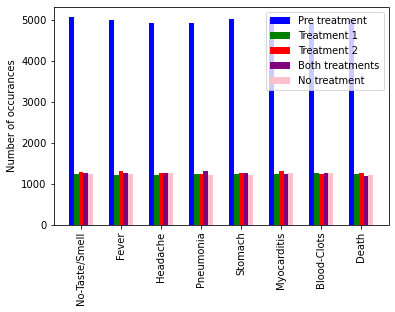

```python
g_treat, g_action, g_outcome = generate_treatment_action_outcome(10000)
pipe_test2 = Pipeline_treatment(g_treat, g_action, g_outcome)

pipe_test2.print_treatment_efficacy(log=False)
pipe_test2.plot_symptoms()
```

## Running pipeline on real data

#### Effect of gene on symptoms

In this section, we will apply the pipelines on the real data. We start with evaluating the effect of genes on the symptoms. For each symptom we compute the mean effect, and then the effect of the each individual gene on the symptoms.

```python
pipe = Pipeline_observational(obs_data)
for s in symptom_names:
    print(s)
    effect = []
    for i in range(0,128):
        effect.append(pipe.estimate_gene_effect(symptoms[s], genes.iloc[:,i]))
    print(f'Mean effect:{np.mean(effect)}')
    relevant_genes = pipe.select_features(symptoms[s],genes, 0.9)
    print(f'Relevant genes: {relevant_genes}')
    for r in relevant_genes:
        print(f'Probability of {s} with gene {r}:  {pipe.estimate_gene_effect(symptoms[s], genes.iloc[:,r])}')
    print("")
```

```
Covid-Recovered
Mean effect:0.04953241804599717
Relevant genes: [31, 55, 97, 98, 120]
Probability of Covid-Recovered with gene 31:  0.05078039129479006
Probability of Covid-Recovered with gene 55:  0.052205955582113335
Probability of Covid-Recovered with gene 97:  0.05110339149816269
Probability of Covid-Recovered with gene 98:  0.050889573601033695
Probability of Covid-Recovered with gene 120:  0.050763962592867015

Covid-Positive
Mean effect:0.2219938717517035
Relevant genes: [3, 14, 17, 27, 37, 38, 40, 45, 48, 57, 67, 72, 90, 105, 120, 123, 126]
Probability of Covid-Positive with gene 3:  0.2248106930930451
Probability of Covid-Positive with gene 14:  0.22406970702266277
Probability of Covid-Positive with gene 17:  0.22507942216627705
Probability of Covid-Positive with gene 27:  0.22423504034513062
Probability of Covid-Positive with gene 37:  0.2240848169633927
Probability of Covid-Positive with gene 38:  0.22420852891241386
Probability of Covid-Positive with gene 40:  0.22449386656028722
Probability of Covid-Positive with gene 45:  0.22430616652003518
Probability of Covid-Positive with gene 48:  0.22441723428480115
Probability of Covid-Positive with gene 57:  0.2249235842985843
Probability of Covid-Positive with gene 67:  0.22443850480711694
Probability of Covid-Positive with gene 72:  0.22653442287228703
Probability of Covid-Positive with gene 90:  0.22422928709055875
Probability of Covid-Positive with gene 105:  0.2242212026080657
Probability of Covid-Positive with gene 120:  0.22438272223000982
Probability of Covid-Positive with gene 123:  0.22401098463742736
Probability of Covid-Positive with gene 126:  0.22412549585286692

No-Taste/Smell
Mean effect:0.01437724338606824
Relevant genes: [19, 30, 39, 40, 54, 76, 85, 96]
Probability of No-Taste/Smell with gene 19:  0.015342062323397142
Probability of No-Taste/Smell with gene 30:  0.015186028853454821
Probability of No-Taste/Smell with gene 39:  0.015259675155404051
Probability of No-Taste/Smell with gene 40:  0.015139124364216616
Probability of No-Taste/Smell with gene 54:  0.015052211733108853
Probability of No-Taste/Smell with gene 76:  0.015374116891457932
Probability of No-Taste/Smell with gene 85:  0.015128744614768059
```

[output cut: 43 more lines]

```

Blood-Clots
Mean effect:0.010060037634143032
Relevant genes: [2, 14, 23, 48, 60]
Probability of Blood-Clots with gene 2:  0.010704157846387346
Probability of Blood-Clots with gene 14:  0.010891722291058795
Probability of Blood-Clots with gene 23:  0.010738711354637444
Probability of Blood-Clots with gene 48:  0.010786409124503127
Probability of Blood-Clots with gene 60:  0.010672955849139567

Death
Mean effect:0.0033807966482094463
Relevant genes: [15, 26]
Probability of Death with gene 15:  0.0038765886020302133
Probability of Death with gene 26:  0.003923677501593371
```

#### The vaccine efficacy

Before running the pipeline on the real data, we split the data into the vaccinated and unvaccinated groups. This will be used for the finding the efficacy of the vaccination.

```python
symptom_names = ['Covid-Recovered', 'Covid-Positive', 'No-Taste/Smell', 'Fever', 'Headache', 'Pneumonia', 'Stomach', 'Myocarditis', 'Blood-Clots', 'Death']
vacced = obs_data[np.sum(obs_data.iloc[:,-3:], axis=1) == 1]
un_vacced = obs_data[np.sum(obs_data.iloc[:,-3:], axis=1) == 0]
prior_probs= [np.sum(obs_data.iloc[:,i]) / len(obs_data) for i, key in enumerate(symptom_names)]
```

```python
pipe.print_vaccine_efficacy(vacced, un_vacced,prior_probs)
```

```
Covid-Recovered: 28.965 - (20.096, 36.844)
Covid-Positive : 21.464 - (19.625, 23.261)
No-Taste/Smell : 47.521 - (41.649, 52.867)
Fever          : 51.575 - (44.956, 57.412)
Headache       : 45.473 - (29.024, 58.391)
Pneumonia      : 57.810 - (51.546, 63.343)
Stomach        : 50.542 - (25.975, 67.430)
Myocarditis    : 44.531 - (28.361, 57.143)
Blood-Clots    : 57.190 - (50.870, 62.794)
Death          : 93.394 - (90.512, 95.678)
```

This output illustrate the efficacy of the vaccines over all of the symptoms. The vaccine has the highest effect on death symptom with 93.393 percent, and has the lowest on getting infect with Covid19.

##### Each vaccine type

For each vaccination type, these tables show the estimated efficacy and the credible intervals for each effect. Depending on the width of the credible intervals we are more or less confident about the efficacy. A really wide interval is often a result of few observations. The vaccines are, as expected, effective in preventing death. However, less effective in protecting against Covid.

```python
pipe.print_vaccine_efficacy(vacced, un_vacced,prior_probs,vaccine_type = True)
```

```
Covid-Recovered: 19.633 - (6.037, 31.596)
Covid-Positive : 11.296 - (8.512, 13.994)
No-Taste/Smell : 34.419 - (24.550, 43.361)
Fever          : 43.590 - (32.760, 53.046)
Headache       : 30.767 - (2.716, 52.380)
Pneumonia      : 54.129 - (44.181, 62.766)
Stomach        : 28.704 - (-16.711, 59.476)
Myocarditis    : 36.093 - (10.488, 55.862)
Blood-Clots    : 48.746 - (38.197, 57.980)
Death          : 95.704 - (91.556, 98.435)

Covid-Recovered: 28.837 - (16.202, 39.832)
Covid-Positive : 20.584 - (17.978, 23.110)
No-Taste/Smell : 43.109 - (34.090, 51.197)
Fever          : 45.703 - (35.292, 54.880)
Headache       : 39.907 - (14.376, 59.339)
Pneumonia      : 48.345 - (37.766, 57.513)
Stomach        : 70.324 - (42.560, 87.618)
Myocarditis    : 35.284 - (9.530, 55.108)
Blood-Clots    : 47.762 - (37.140, 57.062)
Death          : 92.922 - (87.692, 96.626)

Covid-Recovered: 38.211 - (26.819, 48.240)
Covid-Positive : 32.271 - (29.889, 34.595)
No-Taste/Smell : 64.686 - (57.807, 70.720)
Fever          : 65.183 - (57.072, 72.186)
Headache       : 65.346 - (46.583, 79.112)
Pneumonia      : 70.765 - (63.135, 77.297)
Stomach        : 52.328 - (16.626, 75.676)
Myocarditis    : 61.919 - (43.237, 75.982)
Blood-Clots    : 74.762 - (67.715, 80.770)
Death          : 91.603 - (86.039, 95.694)
```

The output shows the efficacy of the three different vaccines. All vaccines are very good against death, especially the first one. It has an efficiency of 95.704 percent.

#### Estimating side-effects of vaccines

In this section, we are interested in studying the vaccinated samples with negative Covid-19. Then, we compare it with the non-vaccinated with negative Covid-19 symptom.

```python
vacced_neg = vacced[vacced.iloc[:,1]==0]
vacced_pos = vacced[vacced.iloc[:,1]==1]
un_vacced_neg = un_vacced[un_vacced.iloc[:,1]==0]
un_vacced_pos = un_vacced[un_vacced.iloc[:,1]==1]
```

```python
pipe.estimate_side_effects(vacced_neg, un_vacced_neg, 2, 10)
```

|  | p1 (%) | p2 (%) | Diff (%) | Confidence Interval (%) | Null Hypothesis |
| --- | --- | --- | --- | --- | --- |
| No-Taste/Smell | 0.0812 | 0.0568 | 0.0243 | (-0.0067, 0.0554) | not rejected |
| Fever | 9.9028 | 0.5081 | 9.3947 | (9.1613, 9.6281) | rejected |
| Headache | 5.5788 | 1.053 | 4.5258 | (4.3287, 4.7229) | rejected |
| Pneumonia | 0.1332 | 0.1437 | -0.0106 | (-0.0557, 0.0345) | not rejected |
| Stomach | 0.231 | 0.2574 | -0.0264 | (-0.0864, 0.0336) | not rejected |
| Myocarditis | 0.2143 | 0.0468 | 0.1675 | (0.1273, 0.2077) | rejected |
| Blood-Clots | 0.2435 | 0.1103 | 0.1331 | (0.0847, 0.1816) | rejected |
| Death | 0.0354 | 0.0 | 0.0354 | (0.0213, 0.0494) | rejected |

#### Estimaing treatment effects

[output not shown]

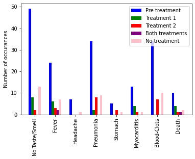

```python
pipe_treat = Pipeline_treatment(treat_data,action_data,outcome_data)
pipe_treat.print_treatment_efficacy()
pipe_treat.plot_symptoms()
```

When estimating the effect of the treatments, we get really unstable results. The credible intervals are really wide and little information is to be drawn fra the data. This is mostly because of few observed symptoms both in the treatment and outcome datasets. However, some of the symptoms were significantly reduced in the outcome data. Blood cloths are for instance completely gone for the patients recieving treatment 1 or both.